# MATH1115 Computer Practical Exam

# Instructions

This is a selection of questions taken from a past exam paper. Answers are not provided by default but can be demonstrated by a tutor.

## Getting started

1. You have been provided a data file, `airbnb.csv` and *this* R Markdown file to complete the exam.
2. Read the data briefing. It will provide useful information about the variables in the dataset.
3. Attempt all questions. You have **100 minutes**, including reading time of 10 minutes.
4. All answers **must** be presented in the appropriate sections and *numbered* according to the question.
5. All plots **must** be in `ggplot2`. Note that diagnostic plots (Residual, QQ plots) that are used to test for data assumptions may remain as base R plots.
6. **Do not edit this template.** Only provide answers in the appropriate blocks (see below).
7. For all hypothesis testing questions, unless stated otherwise, assume that $\alpha = 0.05$.

## Writing your answers

- All answers should be written within the answer alert blocks provided. These alert boxes look like below in the source document:

```
::: {.alert .alert-info}

Write your answers within this block, including code chunks.

:::
```

## Submission

1. When the time is up (100 min), you will have 15 minutes to submit your assignment.
2. **Only .html file submissions are accepted.**
3. You will not be able to submit an incomplete .Rmd file.
4. Rename your final file to `XXXXXXXXXX_MATH1115_Exam.html` where `XXXXXXXXXX` is your SID.

## Acknowledgement

Please acknowledge that you have read the instructions above by replacing `XXXXXXXXXX` with your SID.

**I have acknowledged the instructions in this file. My SID is**:

470033070

# Briefing on Data

**[Airbnb](https://www.airbnb.com.au/)** is a a very popular online global market place for renting accomodation. Each listing features photos and details of the property, reviews from previous guests, and the approximate position on a map. Owners can rent out their whole property or spare rooms to guests.

The data on the **[Inside Airbnb](http://insideairbnb.com/)** site is sourced from publicly available information on the Airbnb site, and has been “analyzed, cleansed and aggregated where appropriate to faciliate public discussion”.

The site has the following mandate: Airbnb claims to be part of the``sharing economy” and disrupting the hotel industry. However, data shows that the majority of Airbnb listings in most cities are entire homes, many of which are rented all year round - disrupting housing and communities.

There is no data dictionary provided on the site. However, most of the variables have names which are fairly descriptive, for example `host name` refers to the name of the home owner.

Other variables include:

- `neighbourhood`: area in Sydney.
- `latitude` : position on map.
- `room_type`: eg private room, entire home/appt.
- `price`: nightly charge, in dollars.
- `minimum_nights`: minimum number of nights that can be booked.
- `availability_365`: total number of nights available for renting in a year.

## Research Task

Hoachen is considering buying some investment properties in Sydney, and wants to research the optimal areas for good rental returns. He downloads the data set from insideairbnb.com for Sydney July 2019. Your task is to help Haochen analyse `airbnb.csv` using this template provided.

The code chunk below will load the tidyverse for you.

## Initial data analysis

Read `airbnb.csv` into your R Markdown file such that the code below works. Your data object should be called `airbnb`. Set `eval=TRUE` once this is done.

```r
airbnb <- read_csv("data/airbnb.csv")
```

**Question 1**: Write a short paragraph on the limitations and ethics associated with this data.

**Question 2**: Focusing on the **price** variable, provide a numerical and graphical summary. Write a short paragraph summarising your findings.

**Question 3**: Pick 2 qualitative variables. Provide a graphical summary. Write a short paragraph summarising your findings.

Q1: The integrity of the data can be really troubling since there are huge amounts of N/As in it and based on the context there is no tidy procedure of how the information was collected in an accurate and trustworthy way. The ethical issue here is these data may be collected without the users who taking these accommodations acknowledging, they have no idea their past trips were being studied.

Also only 3 types of rooms are recorded, they can be seperated more.

Q2:

```r
airbnb %>%
  select(price) %>%
  summary()
```

```
##      price
##  Min.   :    0.0
##  1st Qu.:   75.0
##  Median :  130.0
##  Mean   :  205.8
##  3rd Qu.:  210.0
##  Max.   :36128.0
```

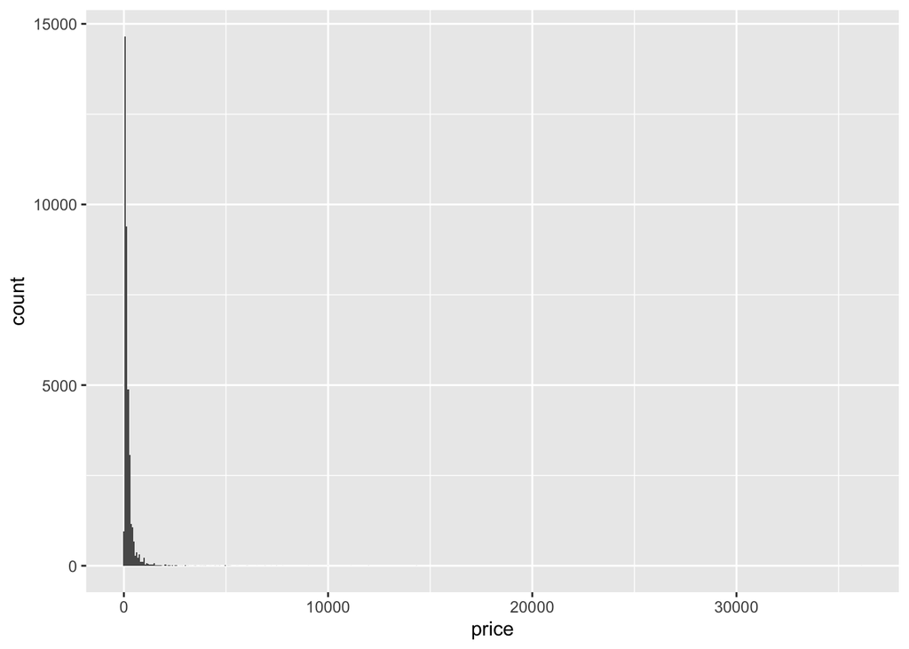

```r
airbnb %>%
  ggplot(aes(price)) +
  geom_histogram(binwidth = 70)
```

The price data is super right-skewed, leaving some potential issues for statistical studies.

Q3:

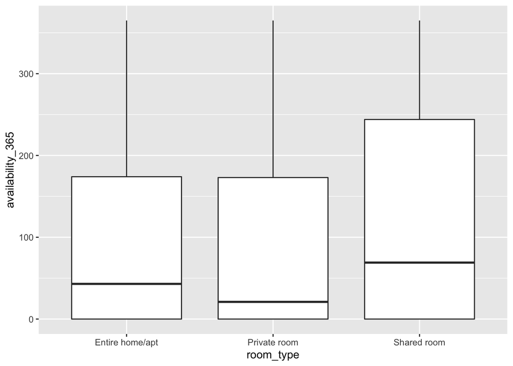

```r
airbnb %>%
  select(room_type, availability_365) %>%
  ggplot(aes(room_type, availability_365)) +
  geom_boxplot()
```

Based on the graphical feedback, we can see among 3 room types observed in our data set, a shared room is more likely to be available throughout a year comparing to a whole home/apartment and the lowest avalibility gpes to the private room.

## Simple linear regression

**Research Question**: Haochen is interested in whether there is a linear association between **latitude** and **price**. He does this on a random sample of 100 rows of the data frame, using the `sample_n()` function.

The code for the sampling technique is below, and the new data object is called `data1`. Activate the code chunk using `eval=TRUE` or copy it into your answers. Perform a simple linear regression analysis. Interpret your findings.

```r
# generate a sample - DO NOT CHANGE
set.seed(1)
data1 <- sample_n(airbnb, 100) # use this data
```

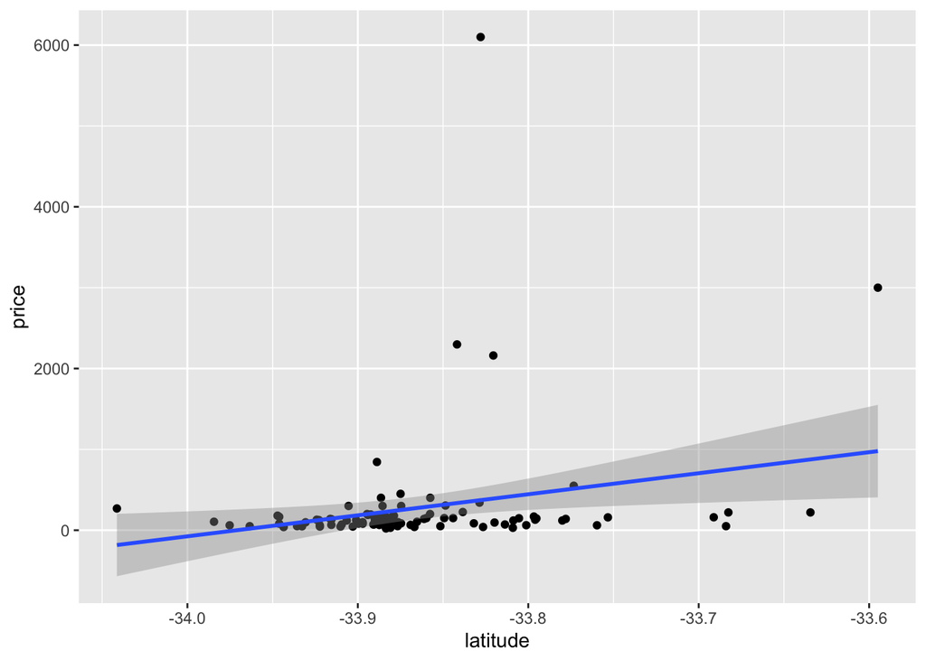

```r
data1 %>%
  ggplot(aes(latitude, price)) +
  geom_point() +
  geom_smooth(method = "lm")
```

The scatter plot of these 2 variables shows although there are 5-7 outliers having an extremely high price values, it overall fits into a linear regression model. To confirm this, we can use Hypothesis Test:

- $H_0$: There is no such relationship between them.
- $H_1$: There is a linear relationship between these 2 variables.

Now the assumptions can be checked, since each house is a quite independent observation than others, for homoscedasticity:

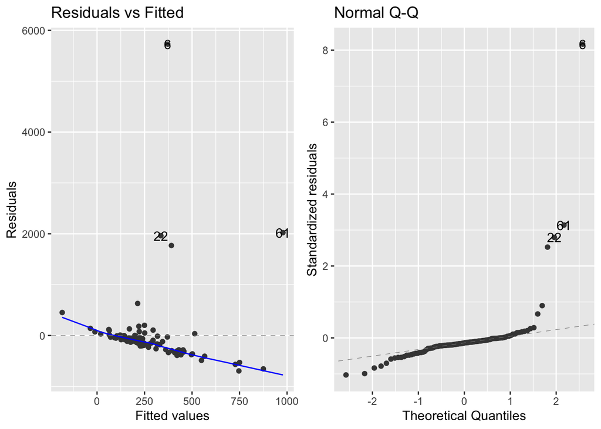

```r
library(ggfortify)
fit <- lm(price ~ latitude, data = data1)
autoplot(fit, which = 1:2)
```

```r
summary(fit)
```

```
##
## Call:
## lm(formula = price ~ latitude, data = data1)
##
## Residuals:
##    Min     1Q Median     3Q    Max
## -696.5 -183.7  -98.0   -9.3 5728.1
##
## Coefficients:
##             Estimate Std. Error t value Pr(>|t|)
## (Intercept)    88373      34939   2.529   0.0130 *
## latitude        2601       1032   2.522   0.0133 *
## ---
## Signif. codes:  0 '***' 0.001 '**' 0.01 '*' 0.05 '.' 0.1 ' ' 1
##
## Residual standard error: 706 on 98 degrees of freedom
## Multiple R-squared:  0.06092,    Adjusted R-squared:  0.05134
## F-statistic: 6.358 on 1 and 98 DF,  p-value: 0.0133
```

## Chi-squared test

**Research Question**: It is claimed that there are an equal number of properties in each of the different geographical areas.

By focusing on the **neighbourhood** variable, test this claim, using a sample of the data and $\alpha = 0.01$. The sample has been extracted for you in the code chunk below. Activate the code chunk using `eval=TRUE` or copy it into your answers. In your answer, use H A T P C.

```r
set.seed(94)
data2 <- sample_n(airbnb, 200)
```

Hypothesis:

- $H_0$: There are an equal number of properties in each of the different geographical areas.
- $H_1$: There are no equal number of properties in each of the different geographical areas.

```r
data2 %>%
  group_by(neighbourhood) %>%
  count -> geo

observed <- geo$n
expected <- rep(1/dim(geo)[1], times = dim(geo)[1])
```

And now we can check on assumptions of expected frequencies, since the data’s nature literally assumes its independence:

```r
sum(observed) * expected
```

```
##  [1] 6.451613 6.451613 6.451613 6.451613 6.451613 6.451613 6.451613 6.451613
##  [9] 6.451613 6.451613 6.451613 6.451613 6.451613 6.451613 6.451613 6.451613
## [17] 6.451613 6.451613 6.451613 6.451613 6.451613 6.451613 6.451613 6.451613
## [25] 6.451613 6.451613 6.451613 6.451613 6.451613 6.451613 6.451613
```

which are all greater than 5. Thus, we perform the test:

```r
mychisq <- chisq.test(observed, p = expected)
mychisq
```

```
##
##  Chi-squared test for given probabilities
##
## data:  observed
## X-squared = 545.86, df = 30, p-value < 2.2e-16
```

With test statistic at 545.86, the p-value is way smaller than 0.01. Thus we can reject the null hypothesis at a 1% level of significance and say there is definitely no equal number of properties in each geographical areas.

## Binomial modelling

Haochen wants to know what proportion of listings are entire homes or apartments.

1. Calculate the probability of randomly choosing an entire home or apartment.
2. Model this sampling by a box model with 50 draws with replacement. Calculate the expected value and standard error for the number of entire houses or apartments.
3. Write a short summary of your findings, in context.

```r
airbnb %>%
  count(room_type) %>%
  mutate(probs = n/sum(n))
```

```
## # A tibble: 3 × 3
##   room_type           n  probs
##   <chr>           <int>  <dbl>
## 1 Entire home/apt 23413 0.615
## 2 Private room    13924 0.366
## 3 Shared room       743 0.0195
```

Thus, the entire home/apt of being randomly choosen is 0.615.

```r
box <- c(rep(0, times = 1000 - 615), rep(1, times = 615))

ev <- mean(box)*50

library(multicon)
se <- popsd(box) * sqrt(50)

c(ev,se)
```

```
## [1] 30.750000  3.440748
```

3. From the model, we expect that out of 50 draws, nearly 30 of them should include a entire home/apt as an option, with expected error range of 3.4 draws.

## Data wrangling

Document the code below using comments (i.e. #) and explain what each line is doing. You may add comments above or beside each line.

```r
library(tidyverse) # import the tidyverse package

# Print the airbnb object without the first, third and forth column and save it into df object.
df=airbnb[,-c(1,3,4)] %>%
  print

# Draw a barplot of 12 lowest numbers of properties in geographical area
airbnb %>%
  .[,6] %>%
  table %>%
  sort %>%
  .[1:12] %>%
  barplot(las=2)

# This never happened
# aggregate(airbnb$number_of_reviews, list(data1$neighbourhood), median)

# Find the maximum price in Sydney provided by Airbnb
airbnb %>%
  filter(neighbourhood=="Sydney") %>%
  select(price) %>%
  max
```